# Coursera Reproducible Research Week 2

C Tweed

10/10/2017

## Loading and preprocessing the data

1. Loading the data

```r
library(knitr)
setwd("~/Dropbox/coursera/ReproducibleResearch/Week2")

active_data <- read.csv("activity.csv")
str(active_data)
```

```
## 'data.frame':    17568 obs. of  3 variables:
##  $ steps   : int  NA NA NA NA NA NA NA NA NA NA ...
##  $ date    : Factor w/ 61 levels "2012-10-01","2012-10-02",..: 1 1 1 1 1 1 1 1 1 1 ...
##  $ interval: int  0 5 10 15 20 25 30 35 40 45 ...
```

2. Converting date from factor -> Date

```r
active_data$date <- as.Date(as.character(active_data$date))
```

## What is mean total number of steps taken per day (missing values ignored)?

1. Calculate the total number of steps taken per day

```r
tot_step_day <- tapply(active_data$steps, active_data$date, sum, na.rm = TRUE)
```

2. Make a histogram of the total number of steps taken each day

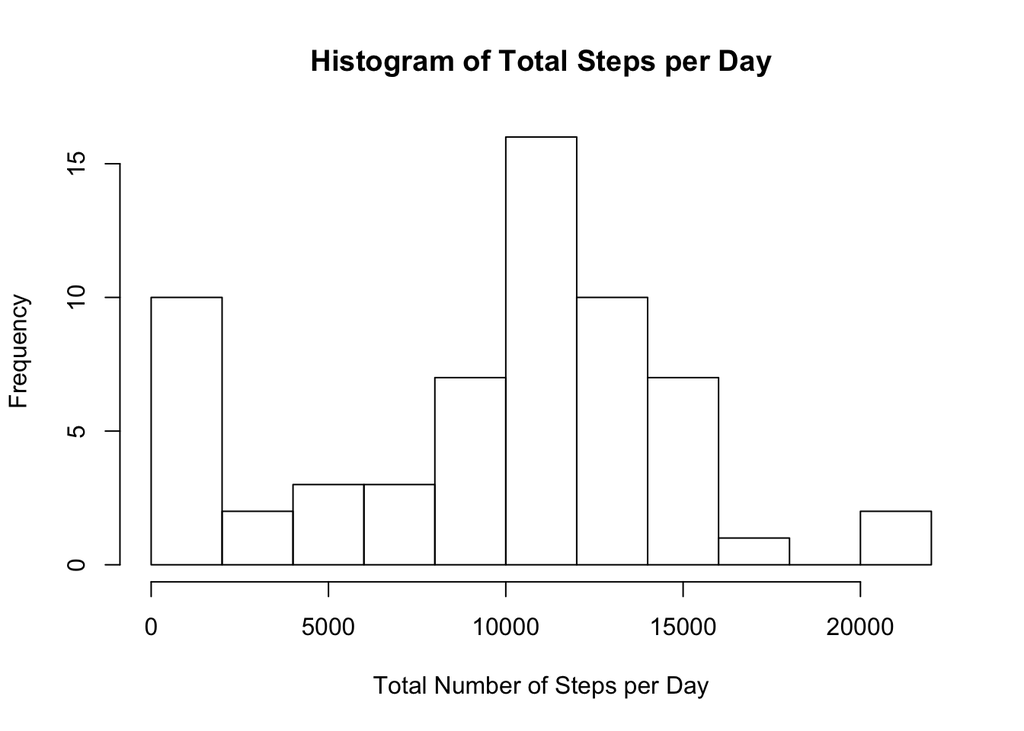

```r
hist(tot_step_day, breaks =10, xlab = "Total Number of Steps per Day", main = "Histogram of Total Steps per Day")
```

3. Calculate and report the mean and median of the total number of steps taken per day

```r
mean_steps <- mean(tot_step_day)
median_steps <- median(tot_step_day)
```

The mean number of steps is 9354.2295082 and the median is 10395 per day

## What is the average daily activity pattern?

1. Make a time series plot (i.e. 𝚝𝚢𝚙𝚎 = “𝚕”) of the 5-minute interval (x-axis) and the average number of steps taken, averaged across all days (y-axis)

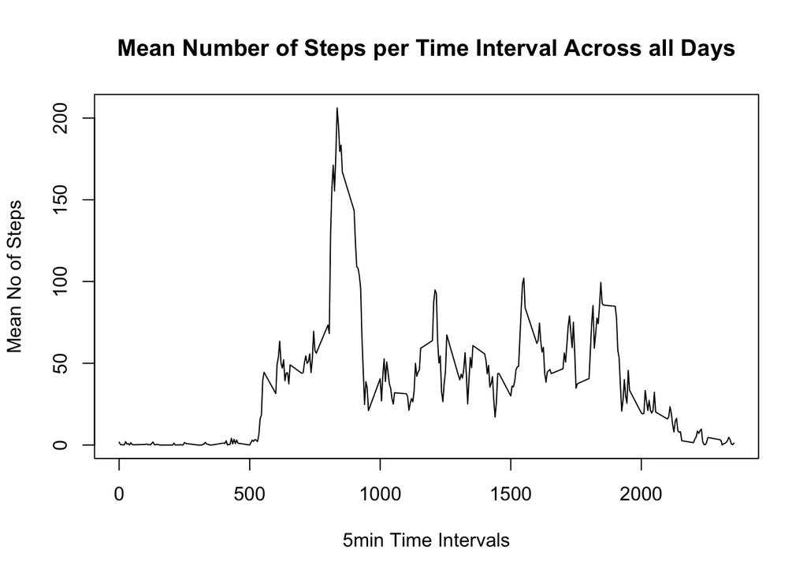

```r
interval_steps <- aggregate(list(steps = active_data$steps), by = list(intervals = active_data$interval), FUN = mean, na.rm = TRUE)

plot(interval_steps$intervals, interval_steps$steps, type = "l", main = "Mean Number of Steps per Time Interval Across all Days", xlab = "5min Time Intervals", ylab = "Mean No of Steps")
```

2. Which 5-minute interval, on average across all the days in the dataset, contains the maximum number of steps?

```r
max_steps <- which.max(interval_steps$steps)
max_interval <- interval_steps$intervals[max_steps]
```

The interval with the highest number of steps on average is 835

## Imputing missing values

1. Calculate and report the total number of missing values in the dataset (i.e. the total number of rows with 𝙽𝙰s)

```r
tot_nas <- sum(is.na(active_data$steps))
```

The total number of missing values in the dataset is 2304

```r
library("Hmisc")
active_data_new <- active_data
active_data_new$steps <- impute(active_data$steps, FUN = mean)
```

[figure not shown]

```r
hist(active_data_new$steps, breaks =10, xlab = "Total Number of Steps per Day", main = "Histogram of Total Steps per Day (Missing Replaced)")
```

```r
mean_replace <- mean(active_data_new$steps)
median_replace <- median(active_data_new$steps)
```

## Are there differences in activity patterns between weekdays and weekends?

1. Create a new factor variable in the dataset with two levels – “weekday” and “weekend” indicating whether a given date is a weekday or weekend day.

```r
active_data_new$weekdays <- as.factor(ifelse(weekdays(active_data_new$date)=="Saturday" | weekdays(active_data_new$date)=="Sunday", "weekend", "weekday" ))
```

2. Make a panel plot containing a time series plot (i.e. 𝚝𝚢𝚙𝚎 = “𝚕”) of the 5-minute interval (x-axis) and the average number of steps taken, averaged across all weekday days or weekend days (y-axis).

```r
library(dplyr)
```

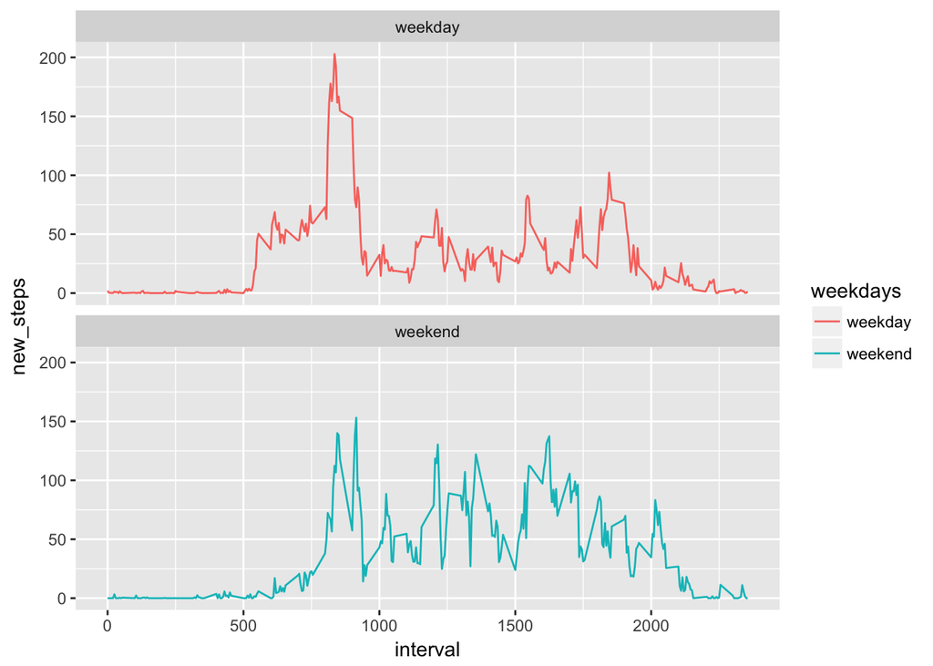

```r
week_steps <- active_data_new %>%
  group_by(interval, weekdays) %>%
  summarise(new_steps = mean(steps))

week_plot <- ggplot(week_steps, aes(x = interval, y = new_steps, col = weekdays)) +
                      geom_line() +
                      facet_wrap(~weekdays, ncol = 1, nrow=2)

print(week_plot)
```